# RSV (ABRYSVO) - Syringe issue

OpenSourcePV

Data Lock Point: Data contains VAERS reports processed as of 2023_11_24 (Year_Month_Day). Flag NEW was defined against reports processed as of 2023_10_27.

# 1 Quantitative Signal status

## 1.1 Disproportionality

The vaccine-event combination “RSV (ABRYSVO) - Syringe issue” was **a signal of disproportionate reporting** with an EB05 value of 2.59.

The threshold for being flagged as a signal of disproportionate reporting is an EB05>=2 meaning that there there is a 95% probability that the reporting of Syringe issue was at least twice post exposure to RSV (ABRYSVO) than post all vaccines. Under the assumption of no causality between RSV (ABRYSVO) and Syringe issue and no bias it would have been expected to observe an EBGM of 1.

It means that the quantified causality criterion of strength of association is **met**.

*It is to be noted that the nature of the spontaneous report does not provide reliable estimates of the strength of association (whatever the choice of the disproportionality method) and that some reporting bias or difference in demographic characteristics might explain the (un)observed disproportion*.

## 1.2 Time-to-onset

The vaccine-event combination “RSV (ABRYSVO) - Syringe issue” was **not a signal of unexpected time-to-onset distribution** with a p-value of the two-sample Kolmogorov-Smirnov test being 1 and distance between the two empirical cumulative distributions being of 0%.

The threshold for being flagged as a signal of unexpected time-to-onset distribution is a P-value of the two-sample Kolmogorov-Smirnov test <0.001 and a distance between the two empirical distributions larger than 20%. Under the assumption of no causality and no bias, it would have been expected that the time-to-onset distribution for “Syringe issue” would have been the same post RSV (ABRYSVO) than post other vaccines. The two-sample Kolmogorov-Smirnov tests this hypothesis.

It means that the quantified causality criterion of temporality is **not met**.

*It is to be noted that the nature of the spontaneous report does not provide reliable estimates of the temporal relationship between the exposure and the occurrence of the events as there is the reporting bias over time: the latter the event occurs after exposure, the less chance it has to be reported. Other biases could distort the reported time-to-onset distribution (media attention, etc.)*

## 1.3 Overall

Based on the screening of the Empirical Bayes Geometric Mean (EBGM) and the screening of the time-to-onset distribution,the vaccine-event combination “RSV (ABRYSVO) - Syringe issue” is **considered as quantitative signal**.

# 2 Signal History

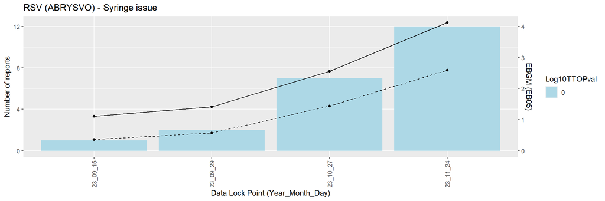

# 3 Case series

## 3.1 Seriousness

A total of 12 reports of Syringe issue were received post exposure to RSV (ABRYSVO). Among them:

- 0 (0.0 %) were fatal cases.
- 0 (0.0 %) were life threatening cases.
- 0 (0.0 %) were hospitalized cases.
- 0 (0.0 %) were emergency room cases.
- 0 (0.0 %) were cases with disabilies.

5 new cases were received since last data refresh.

## 3.2 Demographic characteristics

12 cases of Syringe issue post RSV (ABRYSVO) were reported in VAERS:

- Among them, there were 1 (8.3%) female cases and 0 (0%) male cases while the overall female:male ratio is 63:28%.
- The mean (median) age for patients presenting symptoms of Syringe issue was NaN (NA) years while the overall mean (median) age was 71 (72) years.
- The top 5 contributing US states for patients presenting symptoms of Syringe issue were CO ( 16.7 %) , IN ( 16.7 %) , AZ ( 8.3 %) , CA ( 8.3 %) , IA ( 8.3 %) while overall the top 5 of contributing US states are NA ( 12.9 %) , FL ( 5.6 %) , OH ( 5.6 %) , NY ( 5.4 %) , CA ( 5.3 %)

# 4 Listing of the cases

Narratives can be made visible clicking on the ⊕ symbol.

|  | VAERS_ID | Sex/Age (Years) | Receipt Date | Seriousness status | List of symptoms | new | SYMPTOM_TEXT |
| --- | --- | --- | --- | --- | --- | --- | --- |
| &oplus; | 2679292 | U/NA | 09/05/2023 |  | Syringe issue | No | malfunction of syringes for ABRYSVO where the luerlock broke This is a spontaneous report received from a contactable reporters Pharmacist from product quality group A patient no qualifiers provided r… |
| &oplus; | 2686804 | F/NA | 09/26/2023 |  | Device defective, Syringe issue | No | It looks like we had one syringe over here that is broken This is a spontaneous report received from a contactable reporter Pharmacist from product quality group A female patient received pf 06928316 … |
| &oplus; | 2691544 | U/NA | 10/05/2023 |  | Device connection issue, Device leakage, Product leakage, Syringe issue | No | syringe was not completely sealed as the product was leaking leaking on the side This is a spontaneous report received from a contactable reporters Pharmacist from medical information team A patient n… |
| &oplus; | 2693835 | U/NA | 10/10/2023 |  | Product leakage, Syringe issue | No | the syringe broke and the diluent leaked out the syringe broke and the diluent leaked out This is a spontaneous report received from a contactable reporters Pharmacist from medical information team A … |
| &oplus; | 2695950 | U/NA | 10/14/2023 |  | Device issue, Syringe issue | No | Not able to use one of the syringes because it was leaking This is a spontaneous report received from a contactable reporters Consumer or other non HCP from product quality group A patient no qualifie… |
| &oplus; | 2696770 | U/NA | 10/17/2023 |  | Syringe issue | No | Was reconstituting it and the syringe where the lurer lock placed on the adaptor broke off This is a spontaneous report received from a contactable reporters Pharmacist from product quality group A pa… |
| &oplus; | 2699441 | U/NA | 10/20/2023 |  | Needle issue, Syringe issue | No | When she tried to administer the vaccine medication squirted all over the place she took a look at the plastic cap and noticed that it was warped When she tried to administer the vaccine medication sq… |
| &oplus; | 2716964 | U/NA | 11/22/2023 |  | Syringe issue | Yes | the luer lock broke literally broke off the syringe The information on the batch lot number for rsv vaccine protsubunit pref 2v has been requested and will be submitted if and when received This is a … |
| &oplus; | 2716966 | U/NA | 11/22/2023 |  | Syringe issue | Yes | the spike adapter broke into 2 parts a top and a bottom he spike did not go into the rubber and it locked but did not plunge into it so they used the diluent and it all leaked out and came out of the … |
| &oplus; | 2717476 | U/NA | 11/24/2023 |  | Syringe issue | Yes | it leaked out all over There may have been a crack The initial case was missing the following minimum criteria no adverse event Upon receipt of follow up information on 10Nov2023 this case now contain… |

[output cut: 2 more lines]

# 5 Disclaimer

This analysis is exploratory only and authors cannot be held responsible for any decision made using these data. It is important to distinguish quantitative signals such as disproportionate reporting, unexpected time-to-onset patterns or cluster from safety signals. Only a qualitative review using multiple data source (literature, clinical trials, etc.) and multiple causality criteria assessment could qualify quantitative signals into safety signals.